# ADVANCED TREE-BASED ALGORITHMS

Random Forests and BART

Marco R. Steenbergen

steenbergen@ipz.uzh.ch

University of Zurich

July 28, 2025

## Libraries We Shall Use

- `baguette`
- `bonsai`
- `dbarts`
- `forcats`
- `future`
- `mlbench`
- `partykit`
- `ranger`
- `tidymodels`

*Note:* `future` is an alternative approach to parallel computing. It can be built right into the model specification.

# Overview

## The Limitations of CART

- Although CARTS have many advantages, including ease of interpretation, they also suffer from limitations.
- These include:
  - Susceptability to over-fitting
  - High variance
  - Sensitivity to outliers and noise

## Bagging Helps but $\ldots$

- Bagging reduces the variance, the risk of over-fitting, and the effects of outliers and noise.
- However, it has a tendency to fit the same trees repeatedly.
- This means that predictions across re-samples tend to be correlated.
- As a result, variance reduction is slowed down.

# Random Forests

## Sampling Instances and Features

- Breiman (2001) proposed random forests as an improvement over bagging.
- The central idea of bagging is to sample instances.
- Random forests add to that the idea of sampling features.
  - For each re-sample, we sample a set of features that are then used to fit a decision tree.
- Thus, two elements of randomness are at play.
- This reduces the risk that splits are made on the same features time and again:
  - There is less correlation between predictions.
  - Measures of feature importance become less biased.

## How Many Features?

- We sample $M < P$ features for each tree.
- One way to set $M$ is to follow a rule-of-thumb:
  - $M = \sqrt{P}$ for classification tasks.
  - $M =\frac{P}{3}$ for regression tasks.
- Alternatively and more commonly, we can set $M$ through cross-validation.

## Making Predictions

- Imagine some subset of features $\boldsymbol{x}^* \subset \boldsymbol{x}$ was selected.
- Only those features are used to make a prediction on the OOB instance.
- The OOB error is based on the prediction based on $\boldsymbol{x}^*$.

## Tuning the Random Forest

- $M$, which is called `mtry` in `tidymodels`.
- The number of bootstrap re-samples or trees, $R$, that will be grown; `trees` in `tidymodels`.
- The minimal number of observations at the terminal leaves, i.e., `min_n` in `tidymodels`.

## Random Forests in `tidymodels`

- Comment
- Data
- Flow
- Tuning
- Finalize
- Performance
- We use the Boston Housing data (Harrison and Rubinfeld 1978).
- We predict the median housing value.
- Features include demographics, geography, and politically relevant variables such as pollution, schooling, and taxes.

```r
library(mlbench)
library(tidymodels)
tidymodels_prefer()
data("BostonHousing2")
work_df <- BostonHousing2[,6:19]
set.seed(10)
housing_split <- initial_split(work_df, prop = 0.8)
train <- training(housing_split)
test <- testing(housing_split)
```

```r
library(bonsai)
rf_recipe <- recipe(cmedv ~ ., data = train)
rf_spec <- rand_forest(mtry = tune(),
                       trees = 100,
                       min_n = tune()) %>%
  set_mode("regression") %>%
  set_engine("partykit")
initial_flow <- workflow() %>%
  add_recipe(rf_recipe) %>%
  add_model(rf_spec)
```

```r
# The argument finalize is key because tidymodels needs to look
# at the data to figure out how many features there are.
rf_para <- extract_parameter_set_dials(rf_spec) %>%
  finalize(train)
set.seed(20)
rf_grid <- grid_latin_hypercube(rf_para,
                                size = 25,
                                variogram_range = 0.75,
                                original = TRUE)
set.seed(30)
cv_folds <- vfold_cv(train, v = 10)
rf_metrics <- metric_set(rsq)
doParallel::registerDoParallel()
rf_tune <- initial_flow %>%
  tune_grid(cv_folds, grid = rf_grid, metrics = rf_metrics)
rf_best <- select_best(rf_tune)
rf_best
```

```
# A tibble: 1 × 3
   mtry min_n .config
  <int> <int> <chr>
1     5    18 Preprocessor1_Model21
```

```r
rf_updated <- finalize_model(rf_spec,
                             rf_best)
workflow_new <- initial_flow %>%
  update_model(rf_updated)
rf_fit_final <- workflow_new %>%
  fit(data = train)
```

```r
rf_fit_final %>%
  predict(test) %>%
  bind_cols(test) %>%
  metrics(truth = cmedv, estimate = .pred)
```

```
# A tibble: 3 × 3
  .metric .estimator .estimate
  <chr>   <chr>          <dbl>
1 rmse    standard       3.85
2 rsq     standard       0.861
3 mae     standard       2.65
```

## A Forest of Trees

- There is not a single tree.
- There is now a forest of $R$ trees.
- This helps with performance.
- However, it hampers interpretation.
- But we can get a sense of node importance using `ranger` and permutation.

## Node Importance

- Flow
- Estimates
- Plot Syntax
- Plot

```r
mod_rf <-rand_forest() %>%
  set_engine("ranger",
             num.threads = parallel::detectCores(),
             importance = "permutation",
             verbose = TRUE) %>%
  set_mode("regression") %>%
  set_args(trees = 100)
rf_flow <- workflow() %>%
  add_model(mod_rf) %>%
  add_recipe(rf_recipe)
```

```r
# With new code for using future
library(future)
set.seed(100)
plan(multisession)

fit_rf <- fit_resamples(
  rf_flow,
  cv_folds,
  metrics = metric_set(rsq),
  control = control_resamples(verbose = TRUE,
                              save_pred = TRUE,
                              extract = function(x) x)
)
```

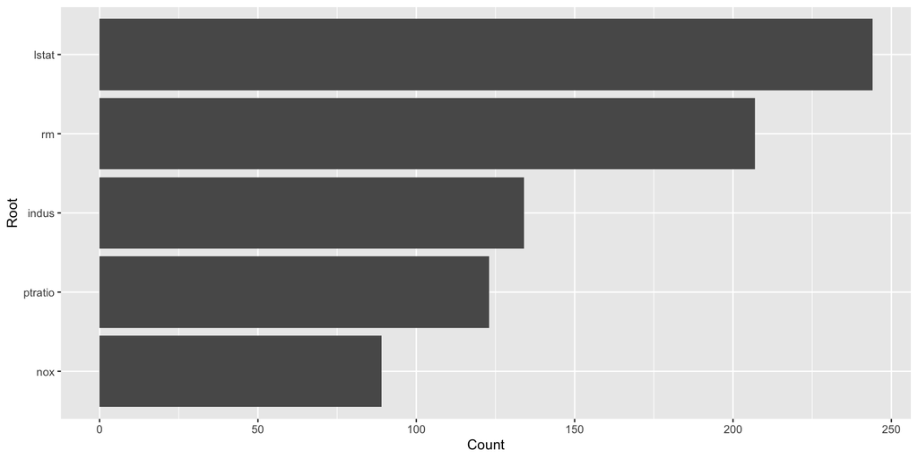

```r
library(forcats)
library(tidyverse)
# extract roots
rf_tree_roots <- function(x){
  map_chr(1:100,
           ~ranger::treeInfo(x, tree = .)[1, "splitvarName"])
}

rf_roots <- function(x){
  x %>%
  select(.extracts) %>%
  unnest(cols = c(.extracts)) %>%
  mutate(fit = map(.extracts,
                   ~.x$fit$fit$fit),
         oob_rmse = map_dbl(fit,
                         ~sqrt(.x$prediction.error)),
         roots = map(fit,
                        ~rf_tree_roots(.))
         ) %>%
  select(roots) %>%
  unnest(cols = c(roots))
}

roots_data <- rf_roots(fit_rf)

# Group the data by roots and count the occurrences of each root
root_counts <- roots_data %>%
  group_by(roots) %>%
  count()

# Filter out roots with counts greater than 75
filtered_root_counts <- root_counts %>%
  filter(n > 75)

# Arrange the data in descending order of counts
sorted_root_counts <- filtered_root_counts %>%
  arrange(desc(n))

# Create a bar plot
plot <- ggplot(sorted_root_counts, aes(x = fct_reorder(roots, n), y = n)) +
  geom_col() +
  coord_flip() +
  labs(x = "Root", y = "Count")

# Display the plot
print(plot)
```

# BART

## What Is BART and Why Should We Care?

- BART = Bayesian Additive Regression Trees (Chipman, George, and McCulloch 2010; Tan and Roy 2019).
- It is a technique that builds different regression trees and adds the results.
- It builds on a Bayesian framework.
- Among the key benefits of BART are:
  - Flexible specification of $\phi(.)$.
  - Automatic detection of interactions and non-linear effects.
  - Probabilistic predictions.
  - Measures of uncertainty.

## The Key Components

1. Regression trees:
   - We make a series of binary decisions that split the data into ever smaller groups, with each group receiving an average.
   - This is akin to other greedy learners.
2. Sum of trees:
   - BART uses many trees, each making its own prediction.
   - The final prediction is the sum of these individual predictions.
   - This is akin to boosted trees.
3. Bayesian:
   - BART incorporates prior distributions for the parameters and updates these to posteriors based on the data.
   - The update is based on MCMC = **Markov Chain Monte Carlo**.

## Sum of Trees

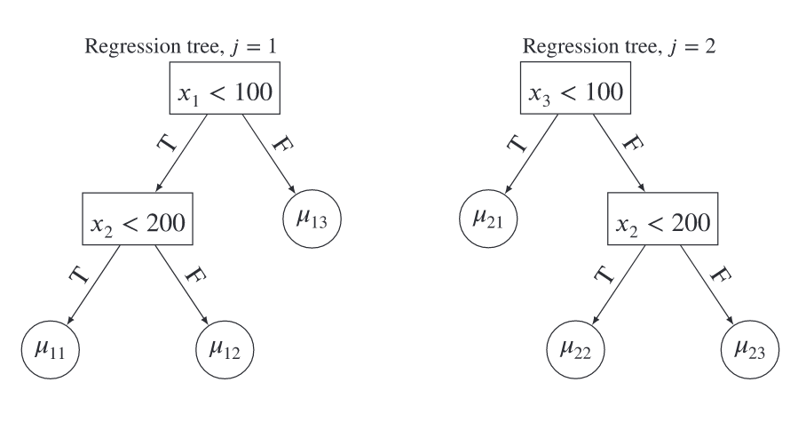

- The sum of trees is

  $$y = \phi(\boldsymbol{x}) + \varepsilon = \sum_{j=1}^m g(\boldsymbol{x};T_j,M_j) + \varepsilon$$

  where $T_j$ is the $j$th binary tree structure and $M_j = \{ \mu_{j1}, \cdots, \mu_{jb_j} \}$ is the vector of terminal node parameters.
- E.g.,
  - An instance with features $(50,80,100)$ receives $\mu_{11} + \mu_{22}$ as the prediction.

## Tree Initialization

- Single root nodes are created:
  - We take the unconditional mean of $Y$, i.e., $\mathbb{E}[Y]$.
  - We divide this over the $m$ trees we plan to construct.
  - The estimator is $\hat{\mu}_{j1} = \frac{\bar{y}}{m}$.
- Getting the residual with respect to a subset of trees:
  - $r_j = y - \sum_{k \neq j} g(\boldsymbol{x}; T_k, M_k)$

## Making Proposals

- Imagine we started with $T_1$ and computed $r_1$.
- We now propose a new tree structure, $T_1^*$. In general, that structure can
  - add new splits
  - remove existing splits
- We now compute the probability of accepting $T_1^*$, taking into consideration:
  - The residual with respect to the status quo: $r_1|T_1$
  - The residual with respect to the proposal: $r_1|T_1^*$
- If $T_1^*$ is accepted, it becomes the new tree structure; otherwise, we stay with $T_1$.
- We repeat the process for a randomly selected second tree.

## Visual Representation of Iterations

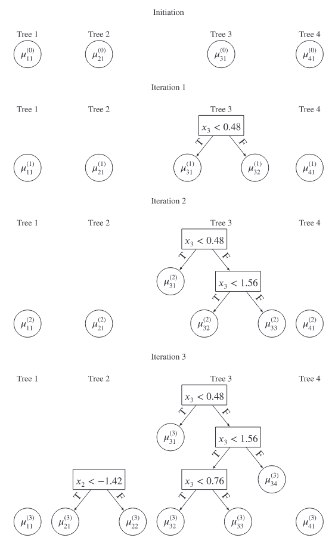

## Prior for Additive Structure

- Given $m$ trees, the prior is

  $$p([T_1,M_1], \cdots, [T_m,M_m], \sigma)$$

  with dispersion parameter $\sigma$.
- If we assume the trees are constructed independently, then we may write this as

  $$p(\sigma) \prod_{j=1}^m p(T_j,M_j|\sigma) = p(\sigma) \left[ \prod_{j=1}^m p(M_j|T_j) p(T_j) \right]$$

## Prior for Additive Structure Cont’d

- We can also write this as

  $$p(\sigma) \left[ \prod_{j=1}^m \left \{ \prod_{i=1}^{b_j} p(\mu_{ji}|T_j) \right \} p(T_j) \right]
  \qquad(1)$$

## More Priors

- $\mu_{ji}|T_j \cal {\sim N}(\mu_{\mu},\sigma_{\mu})$
- $\sigma^2 \sim {\cal IG} \left( \frac{\nu}{2}, \frac{\nu \lambda}{2} \right)$
- For $T_j$ we consider several components:
  - The probability of a node split at depth $d$: $\frac{\alpha}{(1 + d)^{\beta}}$ with $\alpha \in [0,1]$ and $\beta > 0$
    - Higher $\alpha$ increases the likelihood of a split
    - Higher $\beta$ reduces the number of terminal nodes

## More Priors Cont’d

```
-   The probability of selecting $X_p$ for a split.

    -   Often uniform

    -   This can be changed

-   The probability of selecting cutoff $\tau_p$ on $X_p$, which is typically uniform over the range of $X_p$
```

## Moving Back to Boston

- Data
- Split
- Folds

```r
library(mlbench)
library(tidyverse)
data("BostonHousing2")
BostonHousing2 <- BostonHousing2 %>%
  mutate(chas = as.numeric(chas) - 1) %>%
  select(-town, -tract, -lon, -lat, -medv)
```

```r
library(tidymodels)
set.seed(123)
data_split <- initial_split(BostonHousing2, prop = 0.8, strata = cmedv)
train_data <- training(data_split)
test_data <- testing(data_split)
```

```r
cv_folds <- vfold_cv(train_data, v = 5, strata = cmedv)
```

## Workflow

- Recipe
- Specification
- Flow

```r
rec <- recipe(cmedv ~ ., data = train_data) %>%
  step_normalize(all_predictors())
```

```r
library(dbarts)
bart_model <- parsnip::bart(
    trees = tune(),
    prior_terminal_node_coef = tune(),
    prior_terminal_node_expo = tune()
  ) %>%
  set_engine("dbarts") %>%
  set_mode("regression")
```

```r
wf <- workflow() %>%
  add_recipe(rec) %>%
  add_model(bart_model)
```

## Tuning

- Syntax
- Best
- Finalize

```r
pars <- extract_parameter_set_dials(bart_model)
grid <- grid_latin_hypercube(pars,
                             size = 25,
                             variogram_range = 0.5)
set.seed(123)
bart_tuned <- tune_grid(
  wf,
  resamples = cv_folds,
  grid = grid,
  metrics = metric_set(rmse, rsq)
)
```

```r
best_params <- select_best(bart_tuned)
best_params
```

```
# A tibble: 1 × 4
  trees prior_terminal_node_coef prior_terminal_node_expo .config
  <int>                    <dbl>                    <dbl> <chr>
1   270                    0.994                     1.09 Preprocessor1_Model05
```

```r
final_wf <- finalize_workflow(wf, best_params)
final_fit <- fit(final_wf, data = train_data)
```

## Performance

```r
final_results <- final_fit %>%
  predict(test_data) %>%
  bind_cols(test_data) %>%
  metrics(truth = cmedv, estimate = .pred)
final_results
```

```
# A tibble: 3 × 3
  .metric .estimator .estimate
  <chr>   <chr>          <dbl>
1 rmse    standard       2.60
2 rsq     standard       0.917
3 mae     standard       1.93
```

## Exercise

**Your Turn**

Return to the credit data. How well does a random forest or BART predict default?

## References

Breiman, Leo. 2001. “Random Forests.” *Machine Learning* 45 (1): 5–32. https://doi.org/10.1023/A:1010933404324.

Chipman, Hugh A., Edward I. George, and Robert E. McCulloch. 2010. “Bart: Bayesian Additive Regression Trees.” *The Annals of Applied Statistics* 4 (1). https://doi.org/10.1214/09-AOAS285.

Harrison, David, and Daniel L Rubinfeld. 1978. “Hedonic Housing Prices and the Demand for Clean Air.” *Journal of Environmental Economics and Management* 5 (1): 81–102. https://doi.org/10.1016/0095-0696(78)90006-2.

Tan, Yaoyuan Vincent, and Jason Roy. 2019. “Bayesian Additive Regression Trees and the General Bart Model.” *Statistics in Medicine* 38 (25): 5048–69. https://doi.org/10.1002/sim.8347.